# Data-Wrangling-Visualization

Nicole Schlosberg

September 29, 2020

## Data Wrangling

In the hackathon a project was proposed to collect data from student video watching, a sample of this data is available in the file video-data.csv.

```r
#library(tidyverse)
library(tidyr)
library(dplyr)
D1 <- read.csv("video-data.csv", header = TRUE)

#Create a data frame that only contains the years 2018
D2 <- filter(D1, year == 2018)
```

## Histograms

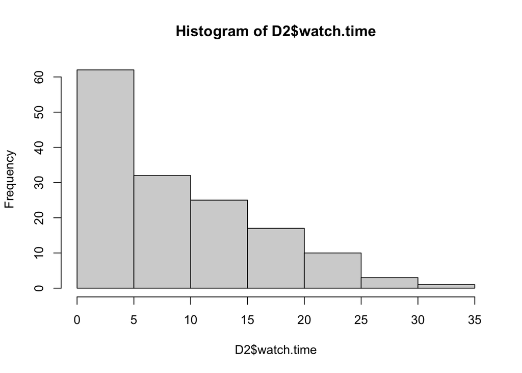

```r
#Generate a histogram of the watch time for the year 2018
hist(D2$watch.time)
```

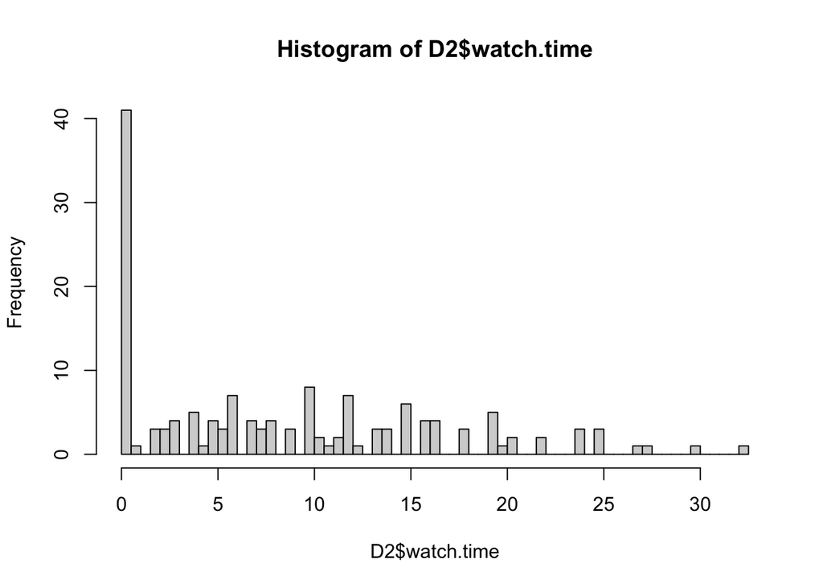

```r
#Change the number of breaks to 100, do you get the same impression?
hist(D2$watch.time, breaks = 100)
```

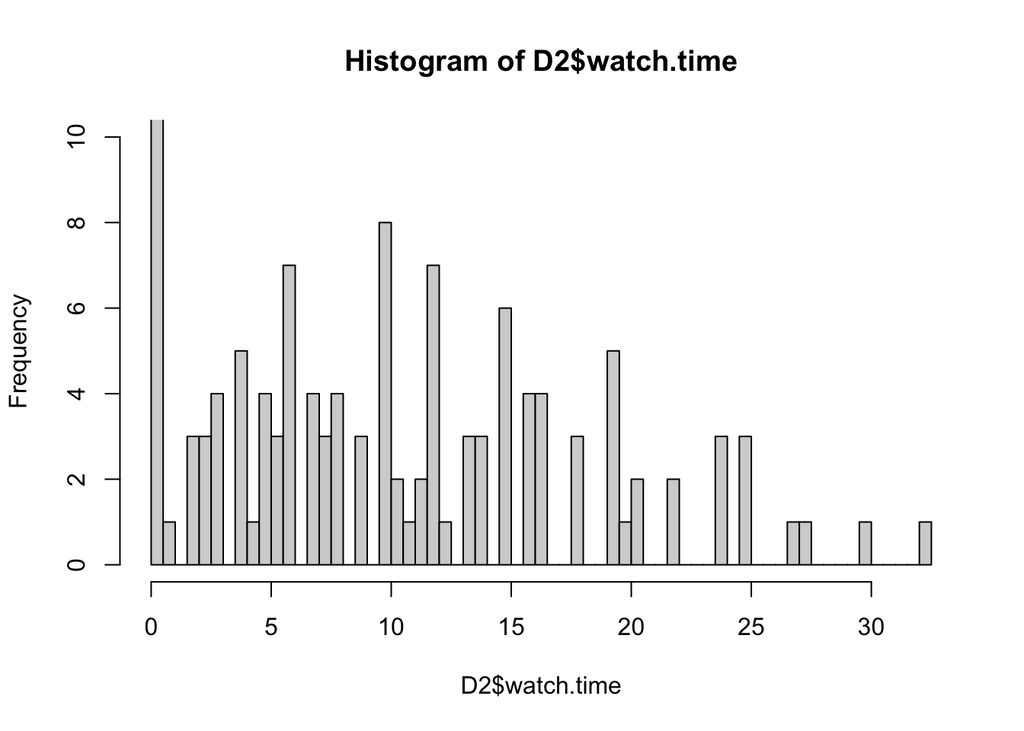

```r
#Cut the y-axis off at 10
hist(D2$watch.time, breaks = 100, ylim = c(0,10))
```

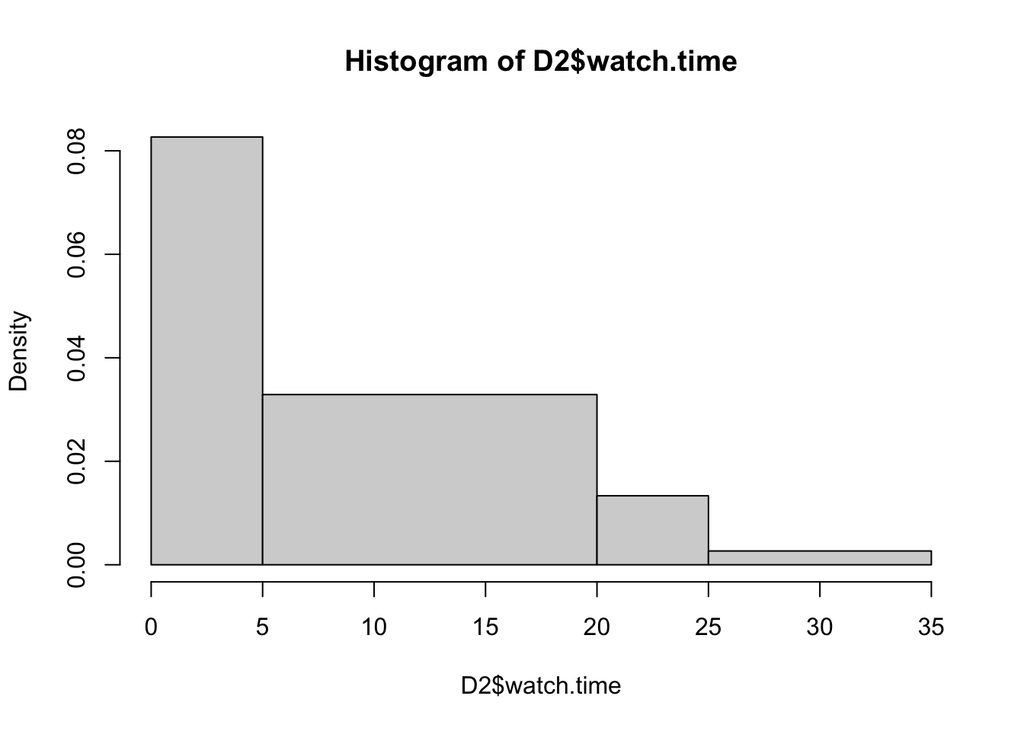

```r
#Restore the y-axis and change the breaks so that they are 0-5, 5-20, 20-25, 25-35
hist(D2$watch.time, breaks = c(0,5,20,25,35))
```

## Plots

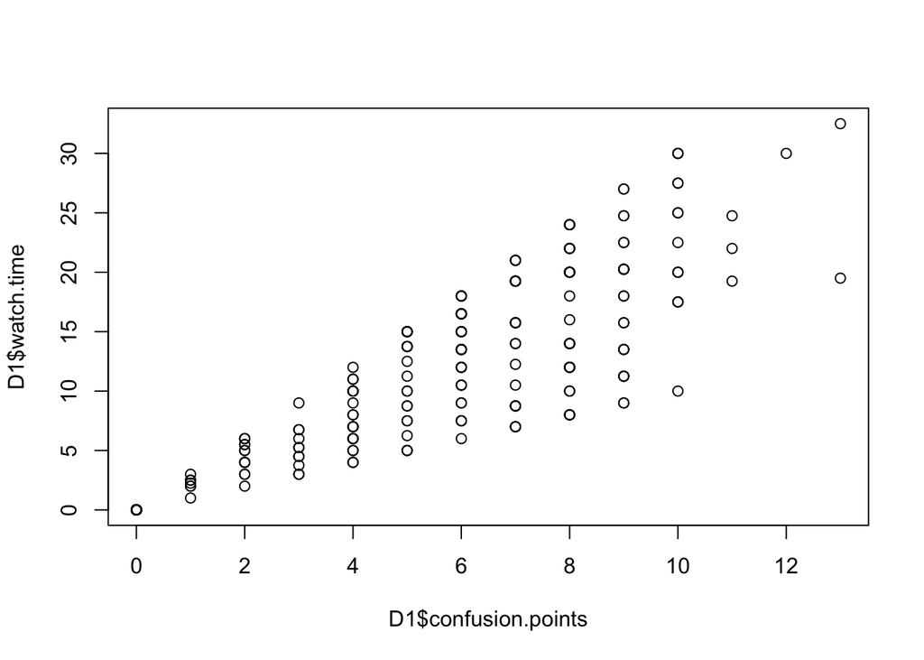

```r
#Plot the number of confusion points against the watch time
plot(D1$confusion.points, D1$watch.time)
```

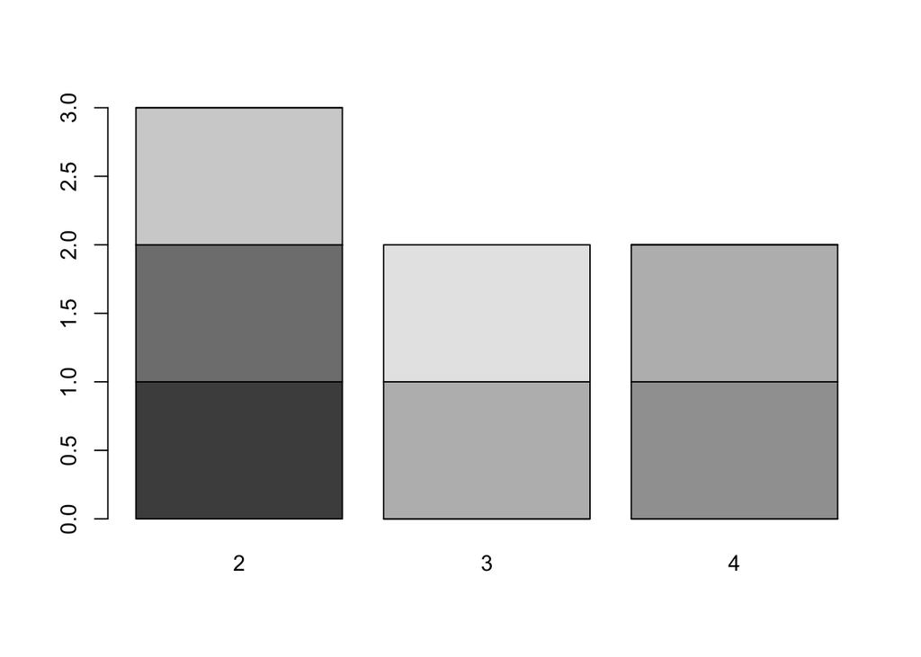

```r
#Create two variables x & y
x <- c(1,3,2,7,6,4,4)
y <- c(2,4,2,3,2,4,3)

#Create a table from x & y
table1 <- table(x,y)

#Display the table as a Barplot
barplot(table1)
```

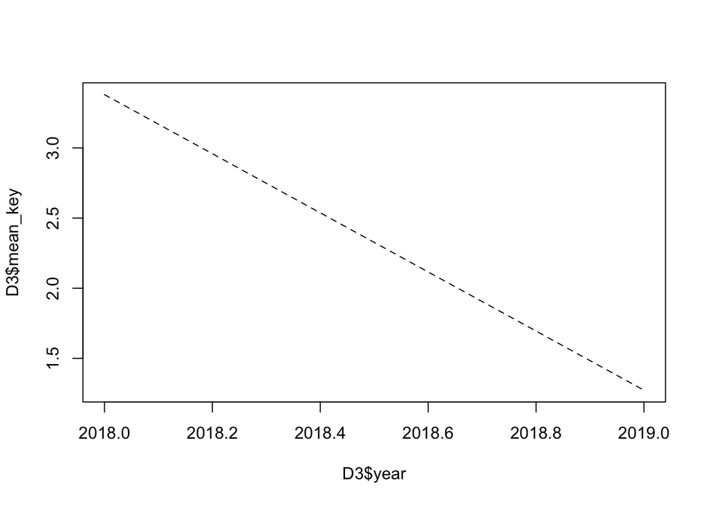

```r
#Create a data frame of the average total key points for each year and plot the two against each other as a lines
D3 <- D1 %>% group_by(year) %>% summarise(mean_key = mean(key.points))
plot(D3$year, D3$mean_key, type = "l", lty = "dashed")
```

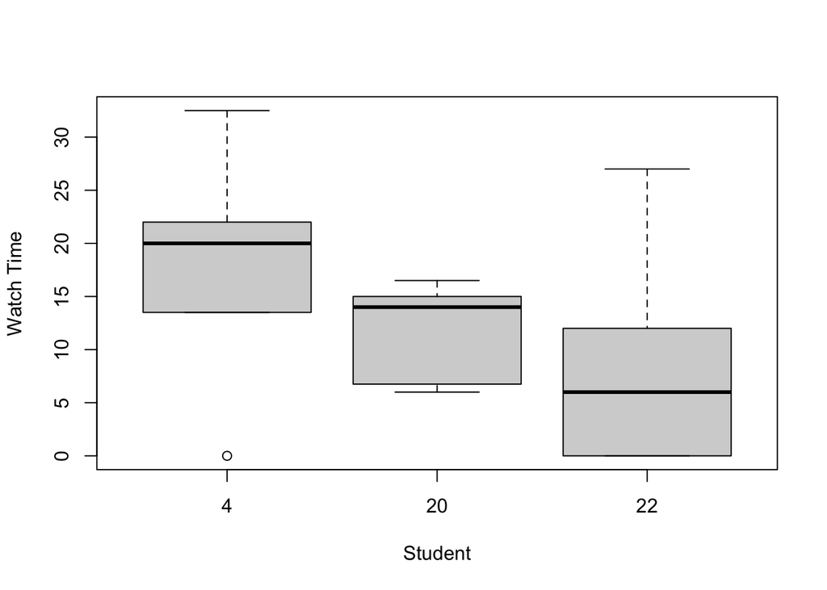

```r
#Create a boxplot of total enrollment for three students
D4 <- filter(D1, stid == 4|stid == 20| stid == 22)
#The drop levels command will remove all the schools from the variable with no data
D4 <- droplevels(D4)
boxplot(D4$watch.time~D4$stid, xlab = "Student", ylab = "Watch Time")
```

## Pairs

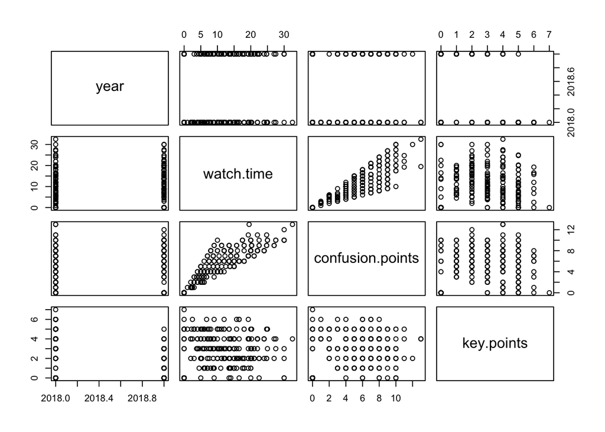

```r
#Use matrix notation to select columns 2, 5, 6, and 7
D5 <- D1[,c(2,5,6,7)]
#Draw a matrix of plots for every combination of variables
pairs(D5)
```

## Part II

1. Create a simulated data set containing 100 students, each with a score from 1-100 representing performance in an educational game. The scores should tend to cluster around 75. Also, each student should be given a classification that reflects one of four interest groups: sport, music, nature, literature.

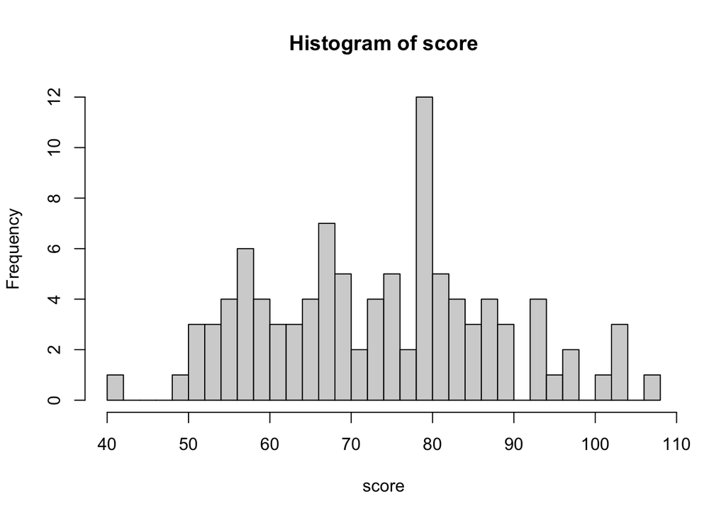

```r
#rnorm(100, 75, 15) creates a random sample with a mean of 75 and standard deviation of 15
#filter() can be used to set max min value and can only work with a data frame, for rows
#select() for columns
#round() rounds numbers to whole number values
#sample() draws a random samples from the groups vector according to a uniform distribution

score <- rnorm(100,75,15)
hist(score,breaks = 30)
```

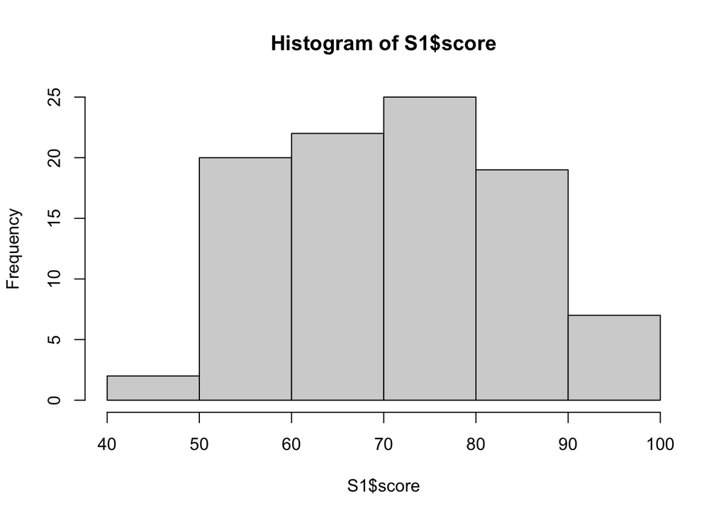

```r
S1 <- data.frame(score)

#Top and tail the scores
S1 <- filter(S1, score <= 100)
hist(S1$score)
```

```r
S2 <- data.frame(rep(100,5)) #repeat 100 5 times and names the column a random name that is not helpful so use the names() command to rename
names(S2) <- "score"
S3 <- bind_rows(S1,S2) #must make sure that the names of the columns and the type match

#S3$score <- ifelse(S3$score >= 100, 100, S3$score)

S3$score <-round(S3$score,0)

interest <- c("sport", "music", "nature", "liturature")
S3$interest <- sample(interest, 100, replace = TRUE)
S3$stid <- seq(1,100,1)
```

2. **Using base R commands, draw a histogram of the scores. Change the breaks in your histogram until you think they best represent your data.

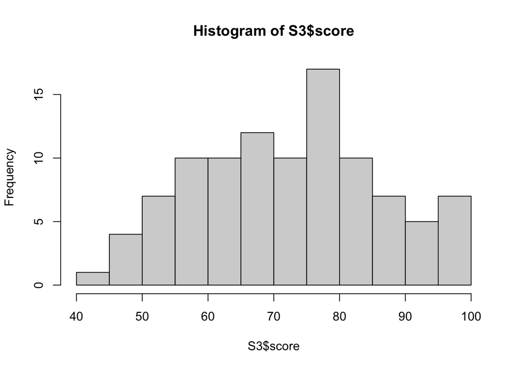

```r
hist(S3$score, breaks = 10)
```

3. Create a new variable that groups the scores according to the breaks in your histogram.

```r
#cut() divides the range of scores into intervals and codes the values in scores according to which interval they fall. We use a vector called `letters` as the labels, `letters` is a vector made up of the letters of the alphabet.
label <- letters[1:10]
S3$breaks <- cut(S3$score, breaks = 10, labels = label)
```

4. Now using the colorbrewer package (RColorBrewer; http://colorbrewer2.org/#type=sequential&scheme=BuGn&n=3) design a pallette and assign it to the groups in your data on the histogram.

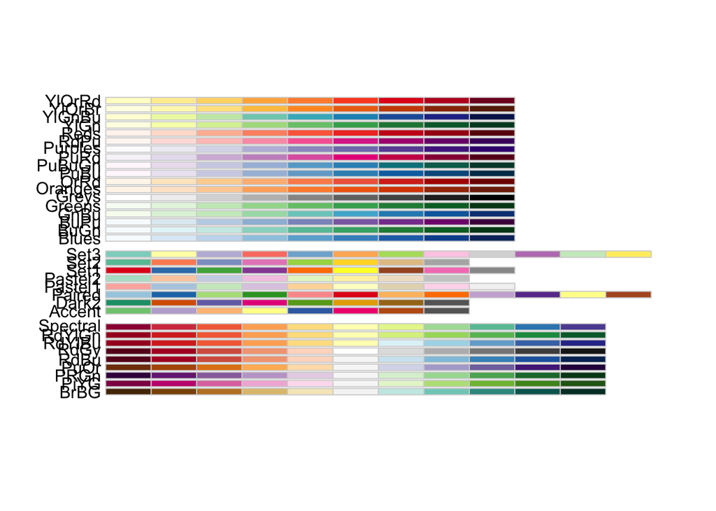

```r
library(RColorBrewer)
#Let's look at the available palettes in RColorBrewer
display.brewer.all()
```

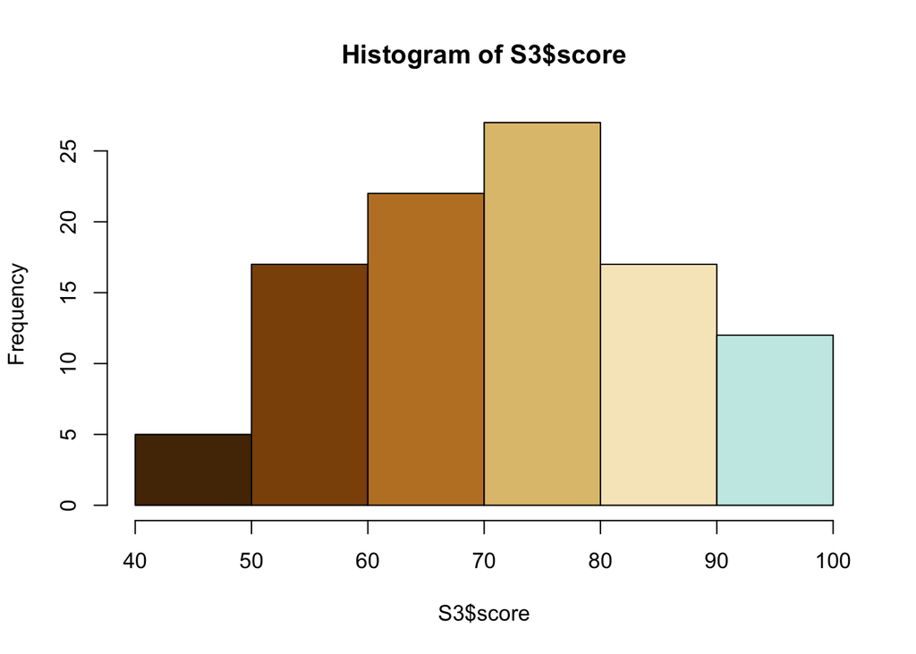

```r
#The top section of palettes are sequential, the middle section are qualitative, and the lower section are diverging.
#Make RColorBrewer palette available to R and assign to your bins

S3$colors <- brewer.pal(10, "BrBG")
#Use named palette in histogram
hist(S3$score, col = S3$colors)
```

5. Create a boxplot that visualizes the scores for each interest group and color each interest group a different color.

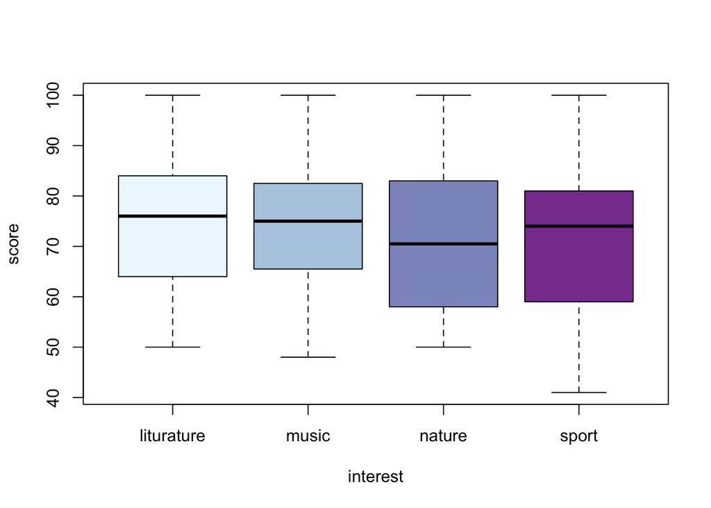

```r
#Make a vector of the colors from RColorBrewer
interest.col <- brewer.pal(4, "BuPu")
boxplot(score ~ interest, S3, col = interest.col)
```

6. Now simulate a new variable that describes the number of logins that students made to the educational game. They should vary from 1-25.

```r
S3$login <- sample(1:25, 100, replace = TRUE)
```

7. Plot the relationships between logins and scores. Give the plot a title and color the dots according to interest group.

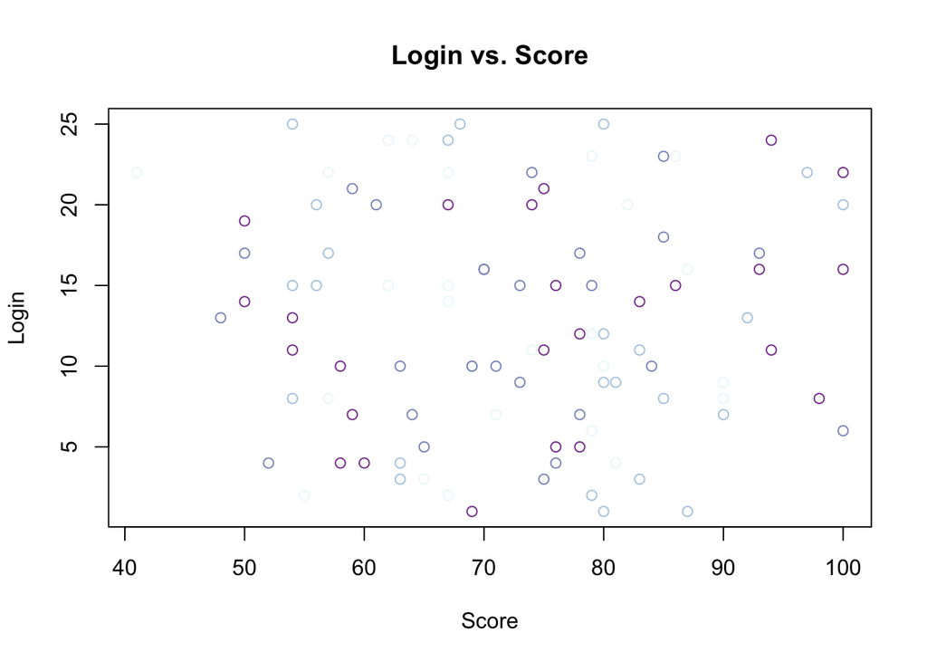

```r
plot(S3$score, S3$login, main = "Login vs. Score", xlab = "Score", ylab = "Login", col = interest.col)
```

8. R contains several inbuilt data sets, one of these in called AirPassengers. Plot a line graph of the the airline passengers over time using this data set.

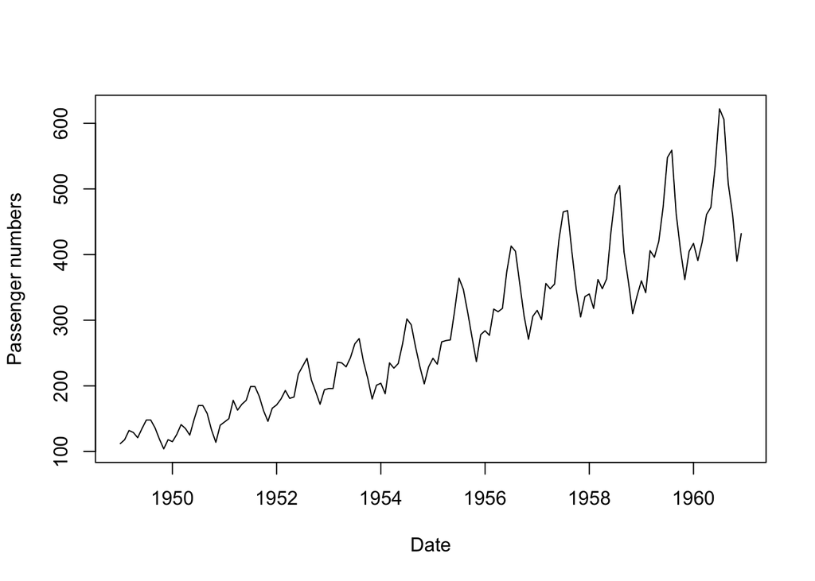

```r
plot(AirPassengers, type = "l", xlab = "Date", ylab = "Passenger numbers")
```

9. Using another inbuilt data set, iris, plot the relationships between all of the variables in the data set. Which of these relationships is it appropriate to run a correlation on?

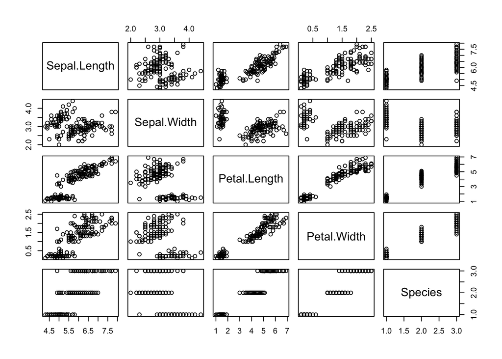

```r
plot(iris)
```

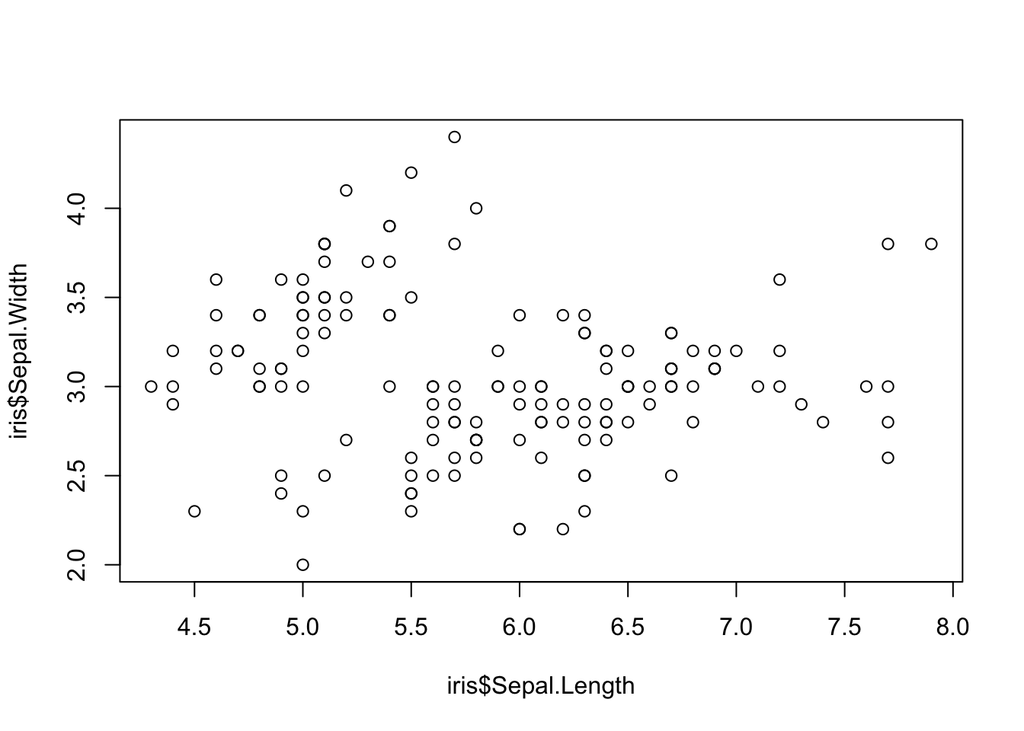

```r
plot(iris$Sepal.Length,iris$Sepal.Width)
```

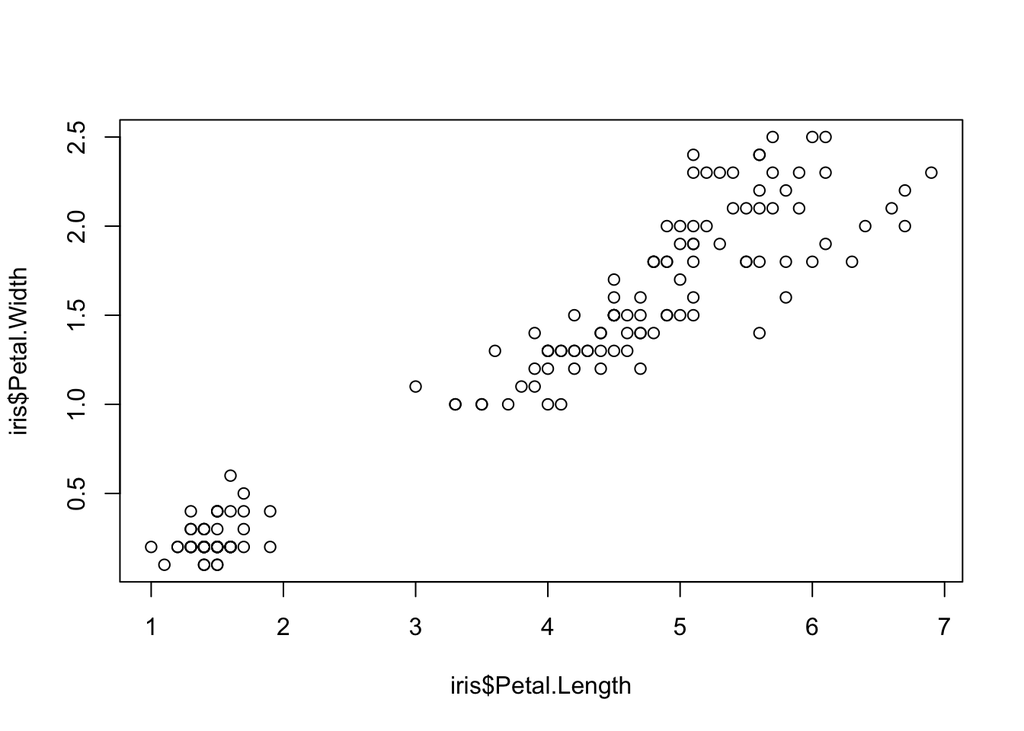

```r
plot(iris$Petal.Length,iris$Petal.Width)
```

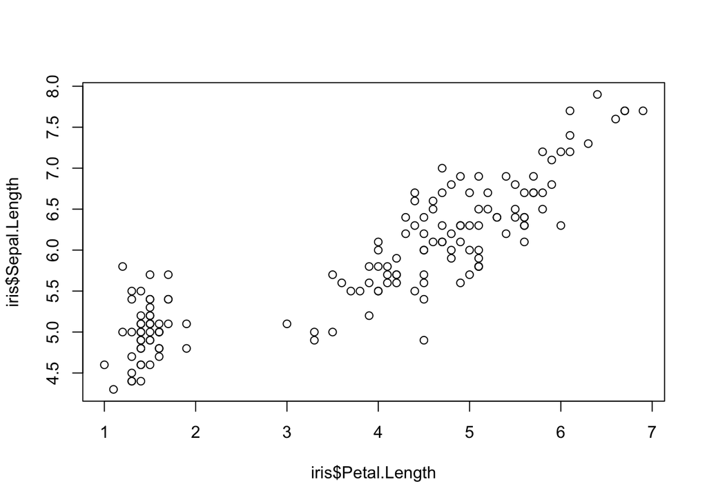

```r
plot(iris$Petal.Length,iris$Sepal.Length)
```

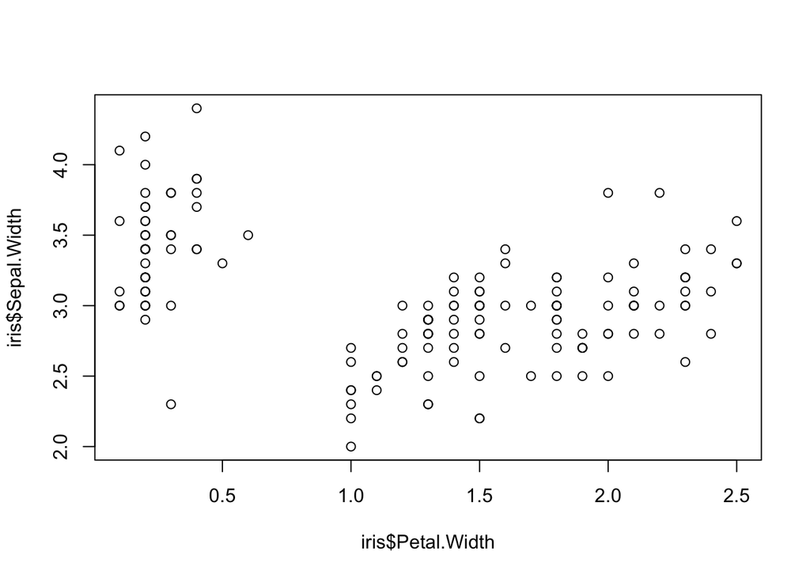

```r
plot(iris$Petal.Width,iris$Sepal.Width)
```

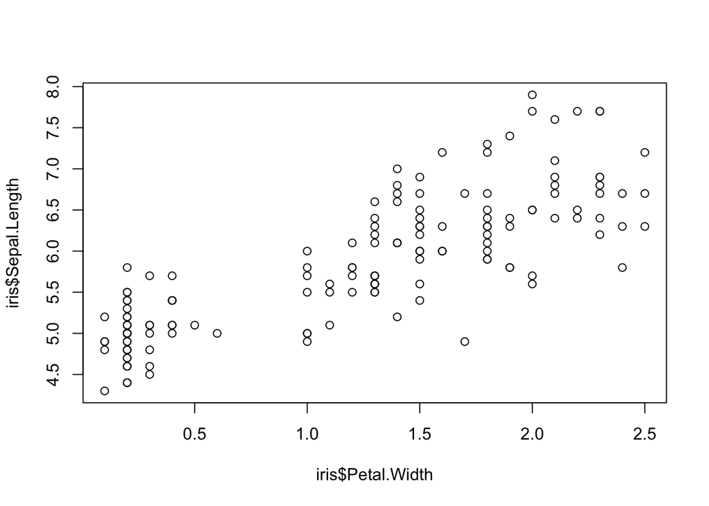

```r
plot(iris$Petal.Width,iris$Sepal.Length)
```

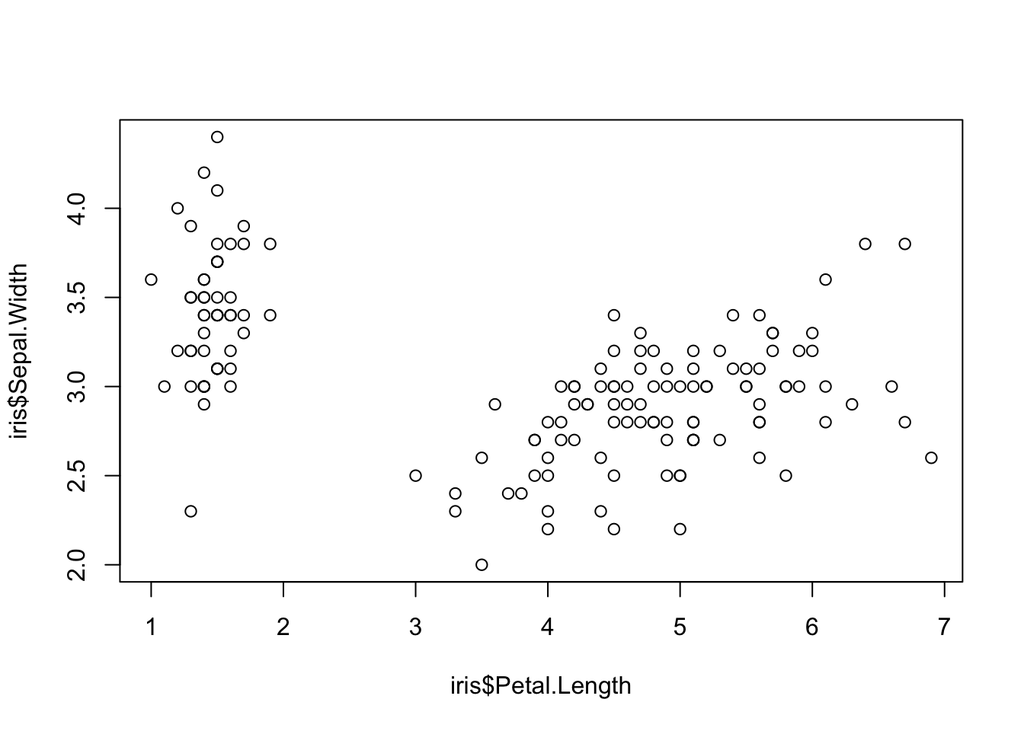

```r
plot(iris$Petal.Length,iris$Sepal.Width)
```

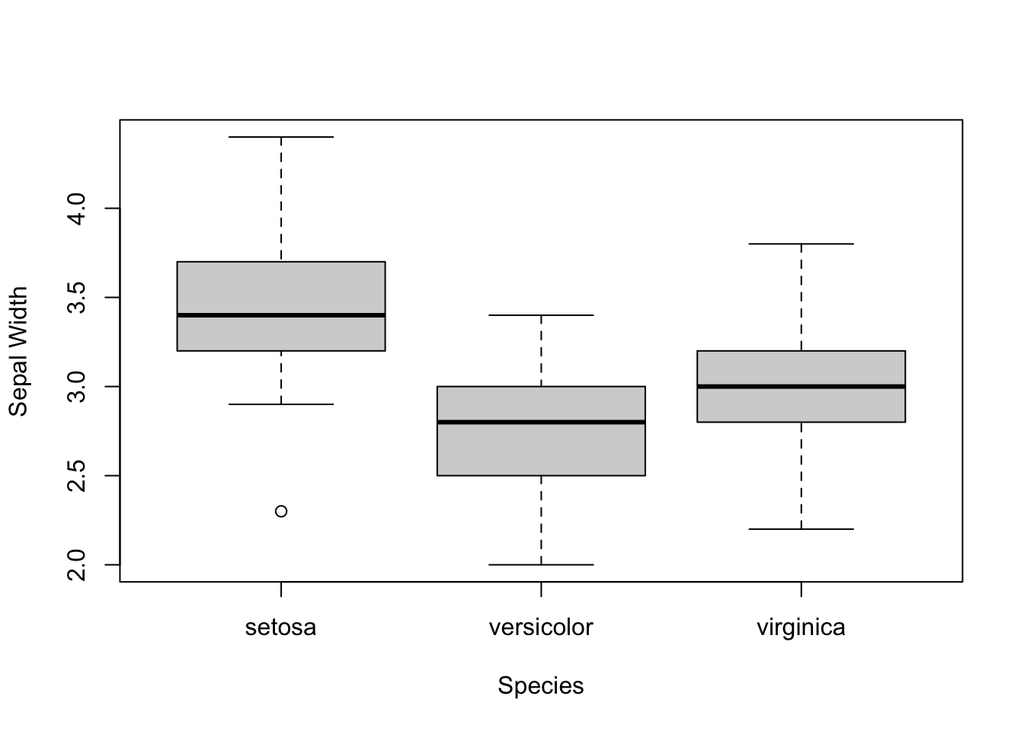

```r
plot(iris$Species,iris$Sepal.Width, xlab = "Species", ylab = "Sepal Width")
```

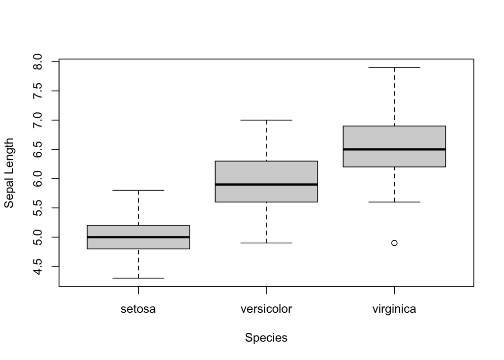

```r
plot(iris$Species,iris$Sepal.Length, xlab = "Species", ylab = "Sepal Length")
```

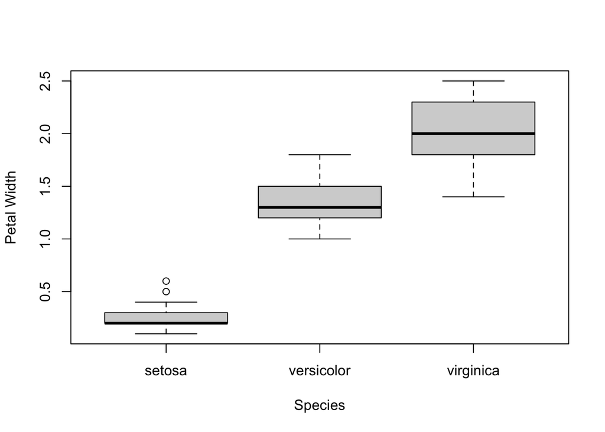

```r
plot(iris$Species,iris$Petal.Width, xlab = "Species", ylab = "Petal Width")
```

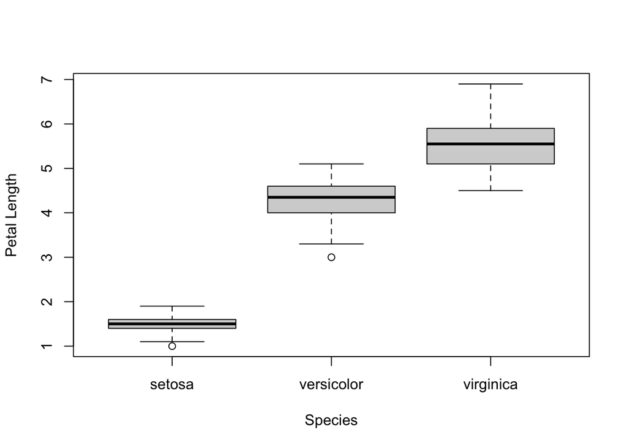

```r
plot(iris$Species,iris$Petal.Length, xlab = "Species", ylab = "Petal Length")
```

```r
#Which of these relationships is it appropriate to run a correlation on?
#Correlation between Sepal Length and Width
corOfSepalLW <- cor(iris$Sepal.Length, iris$Sepal.Width)
#Correlation between Petal Length and Width
corOfPetalLW <- cor(iris$Petal.Length, iris$Petal.Width)
#Correlation between Petal Length and Sepal Length
corOfLengthPS <- cor(iris$Petal.Length, iris$Sepal.Length)
#Correlation between Petal Width and Sepal Width
corOfWidthPS <- cor(iris$Petal.Width, iris$Sepal.Width)
```

# Part III - Analyzing Swirl

## Data

In this repository you will find data describing Swirl activity from the class so far this semester. Please connect RStudio to this repository.

### Instructions

1. Insert a new code block
2. Create a data frame from the `swirl-data.csv` file called `DF1`

The variables are:

`course_name` - the name of the R course the student attempted  
`lesson_name` - the lesson name  
`question_number` - the question number attempted `correct` - whether the question was answered correctly  
`attempt` - how many times the student attempted the question  
`skipped` - whether the student skipped the question  
`datetime` - the date and time the student attempted the question  
`hash` - anonymyzed student ID

3. Create a new data frame that only includes the variables `hash`, `lesson_name` and `attempt` called `DF2`
4. Use the `group_by` function to create a data frame that sums all the attempts for each `hash` by each `lesson_name` called `DF3`

```r
#2
DF1 <- read.csv("swirl-data.csv", header = TRUE)

#3
DF2<- select(DF1, hash, lesson_name, attempt)

#4
DF3 <-  DF2 %>% group_by(hash, lesson_name) %>% summarise(sum_key = sum(attempt), .groups = "keep")
```

5. On a scrap piece of paper draw what you think `DF3` would look like if all the lesson names were column names
6. Convert `DF3` to this format

```r
#6
#Get rid of the NAs so the next step does not throw error and add extra column of NAs
DF3 <- na.omit(DF3)
DF3 <- spread(DF3, lesson_name, sum_key)
```

7. Create a new data frame from `DF1` called `DF4` that only includes the variables `hash`, `lesson_name` and `correct`
8. Convert the `correct` variable so that `TRUE` is coded as the **number** `1` and `FALSE` is coded as `0`

```r
#7
DF4 <- select(DF1, hash, lesson_name, correct)

#8
#Correct misspelled FALS at line 809 in swirl_data.csv and subsequent DF4 dataframe from DF1
DF4$correct <- ifelse(DF4$correct == "FALS", "FALSE", DF4$correct)

#Convert the chr that was created with last back to logi
DF4$correct <- type.convert(DF4$correct)

#Get rid of the NAs so the next steps do not throw "NAs introduced by coercion"
DF4 <- DF4[complete.cases(DF4$correct),]

#Converts logi to num so 0s and 1s instead of FALSE and TRUE
DF4$correct <- as.numeric(DF4$correct)
```

9. Create a new data frame called `DF5` that provides a mean score for each student on each course

```r
#9
DF5 <- DF4 %>% group_by(hash, lesson_name) %>% summarise(mean_key = mean(correct), .groups = "keep")
```

10. Convert the `datetime` variable into month-day-year format and create a new data frame (`DF6`) that shows the average correct for each day

```r
#10
DF6 <- select(DF1, hash, lesson_name, datetime, correct)

#steps to get TRUE/FALSE to 1/0
DF6$correct <- ifelse(DF6$correct == "FALS", "FALSE", DF6$correct)
DF6$correct <- type.convert(DF6$correct)
DF6 <- DF6[complete.cases(DF6$correct),]
DF6$correct <- as.numeric(DF6$correct)

#Creating average correct for each day
DF6 <- DF6 %>% group_by(hash, datetime, correct) %>% summarise(meanByDay = mean(correct), .groups = "keep")

#Convert 'datetime' to month-day-year by converting the parsed num***
#library(lubridate)
#dateConverted <- mdy_hms(DF6$datetime)
#DF6 <- separate_rows(DF6, DF6$datetime, sep = "0")
```